# Homework 1

Krischelle Joyner

In this homework, you will use `diamonds` data set from `ggplot2` package. It is automatically loaded when you execute `library(ggplot2)` so you don’t have to separately load it. Please create a duplicate of `diamonds` and use that for homework. This will avoid corrupting the original data set.

Make sure that you understand the variables in the data by checking the help file by executing `help(diamonds)` in the console. The data has five variables that measure the dimensions.

## Instructions

1. You are expected to recreate each plot **exactly** as shown in this homework.
2. The objective of this homework is to help you develop fine grain control over `ggplot2`. As such, please refrain from exercising artistic freedom!
3. All the plots use `theme_minimal()`. You can set this as your default theme by adding this line in the `setup` chunk **after** you load `ggplot2` library: `theme_set(theme_minimal())`

## Q1 (3 points)

Recreate the following graph. The parameter that controls transparency is set at 0.3. You need not get exactly the same colors but they must be **discrete** and should not follow a color gradient.

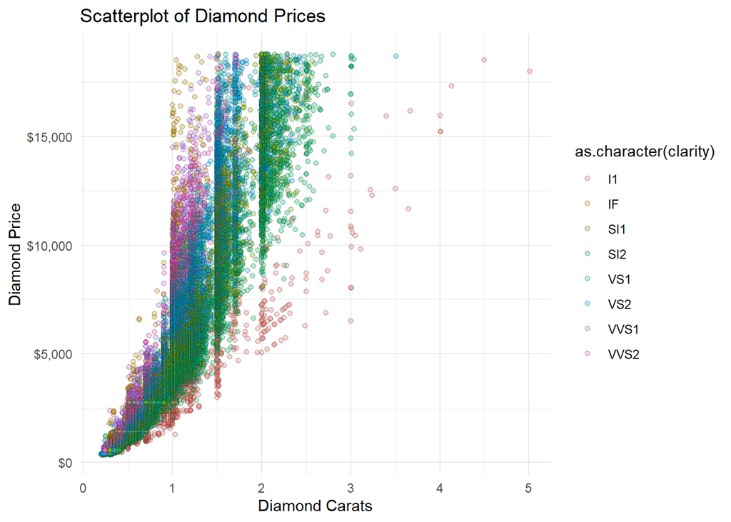

```r
ggplot(diamonds, aes(carat,price)) +
  geom_point(aes(fill = as.character(clarity)),
             color = "black",
             alpha = 0.3,
             shape = 21,
             size = 1.5) +
  labs(title = "Scatterplot of Diamond Prices", x = "Diamond Carats", y = "Diamond Price") +
  scale_y_continuous(labels = scales::dollar_format(prefix = "$"))
```

## Q2 (2 points)

The previous graph looks cluttered. So you decided to use facets instead. Recreate the following graph:

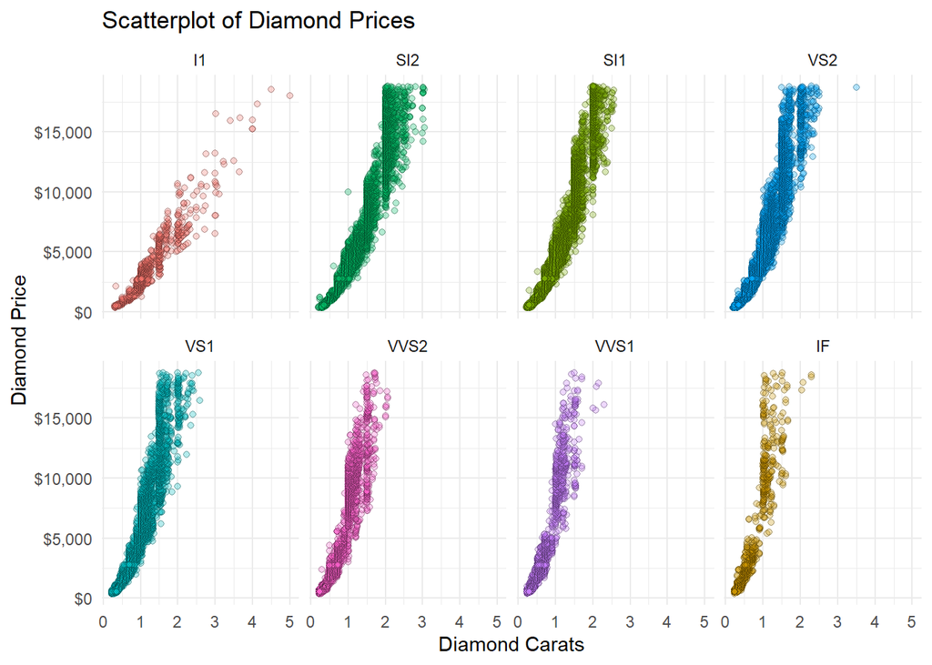

```r
ggplot(diamonds, aes(carat, price)) +
       geom_point(alpha = 0.3, aes(fill = as.character(clarity)), color = "black", shape = 21, size = 1.5,                            show.legend = FALSE) +
       labs(x = "Diamond Carats", y = "Diamond Price",
       title = "Scatterplot of Diamond Prices") +
       scale_y_continuous(labels = scales::dollar_format(prefix = "$")) +
       facet_wrap(~ clarity, ncol = 4)
```

Next, you want to know whether the price of diamonds depends on table and depth. Note the line types. Recreate the following graphs:

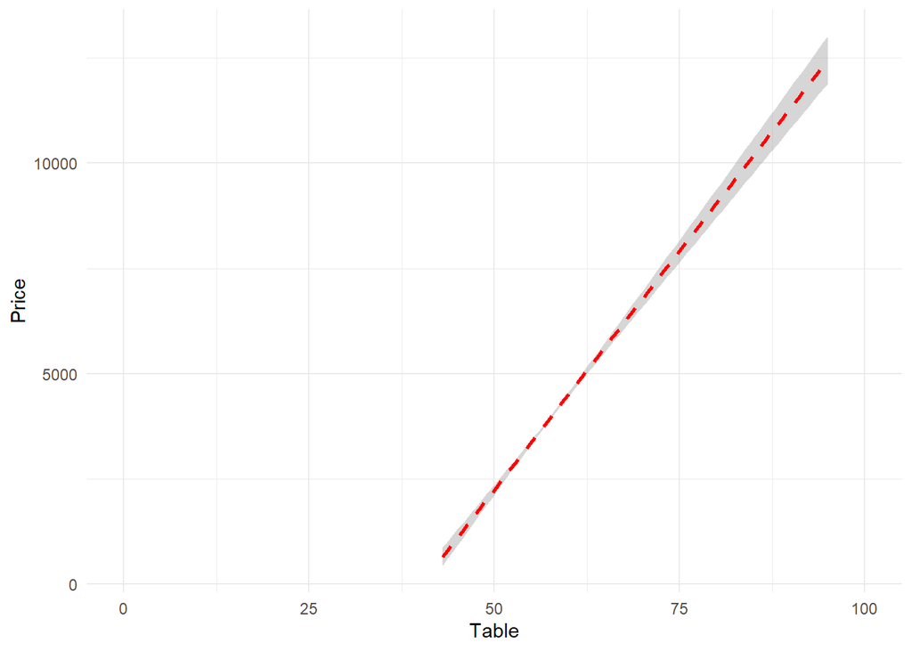

```r
ggplot(diamonds, aes(table, price)) +
       geom_smooth(method = "lm", color = "red", linetype = "dashed") +
       labs(x = "Table", y = "Price") +
       scale_x_continuous(limits = c(0,100),
                          breaks = c(0, 25, 50, 75, 100))
```

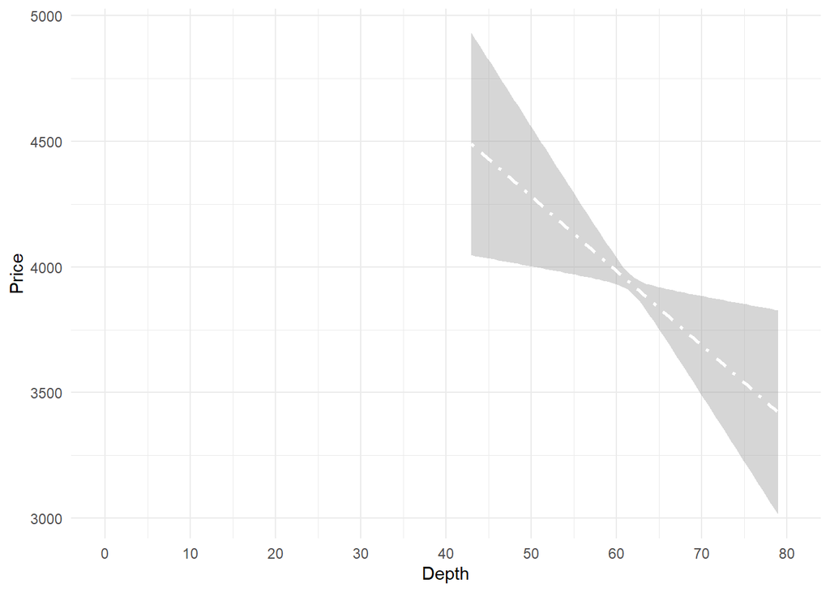

```r
ggplot(diamonds,aes(depth, price)) +
       geom_smooth(method = "lm", color = "white", linetype = "dotdash") +
       labs(x = "Depth", y = "Price") +
       scale_x_continuous(limits = c(0,80),
                          breaks = c(0, 10, 20, 30, 40, 50, 60, 70, 80))
```

## Q4 (5 points)

Recreate each of the following graphs for data exploration:

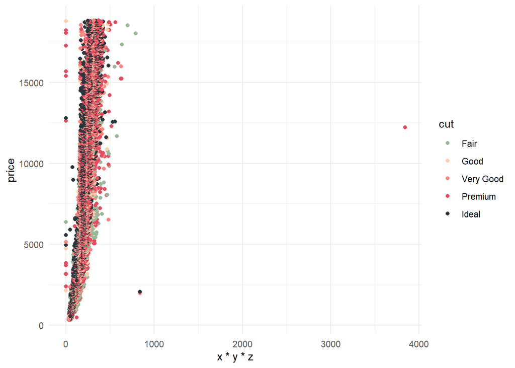

```r
ggplot(diamonds, aes(x*y*z, price)) +
geom_point(aes(color = cut)) +
scale_color_manual(values=c("#99B898", "#FECEAB", "#FF847C", "#E84A5F", "#2A363B"))
```

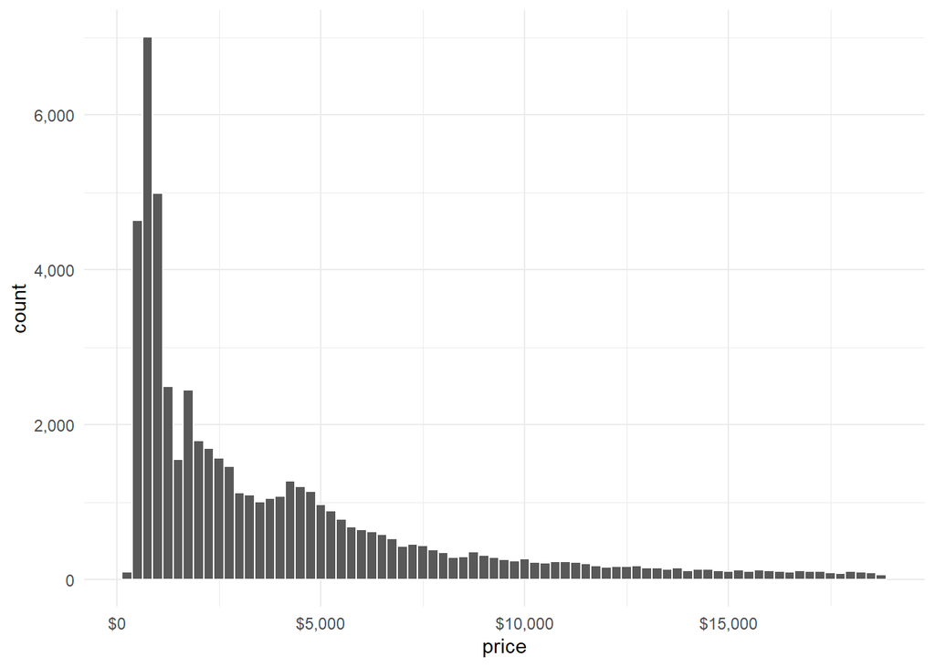

```r
ggplot(diamonds,aes(x = price)) +
       geom_histogram(bins = 75, col="white") +
       scale_y_continuous(labels = scales::comma_format()) +
       scale_x_continuous(labels = scales::dollar_format(prefix = "$"))
```

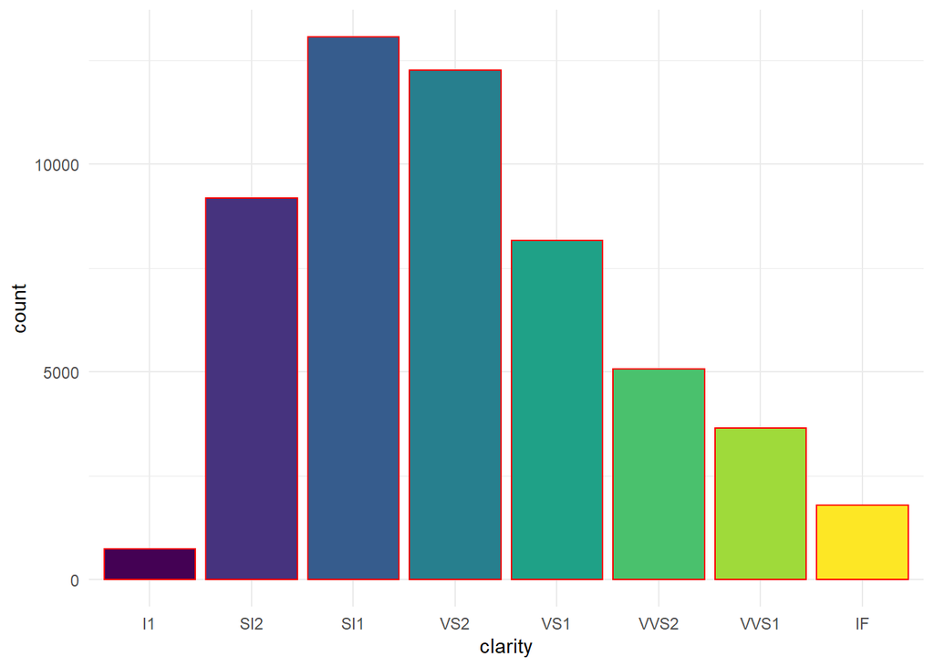

```r
ggplot(diamonds, aes(clarity, fill = clarity)) +
geom_bar(color = "red", show.legend = FALSE)
```

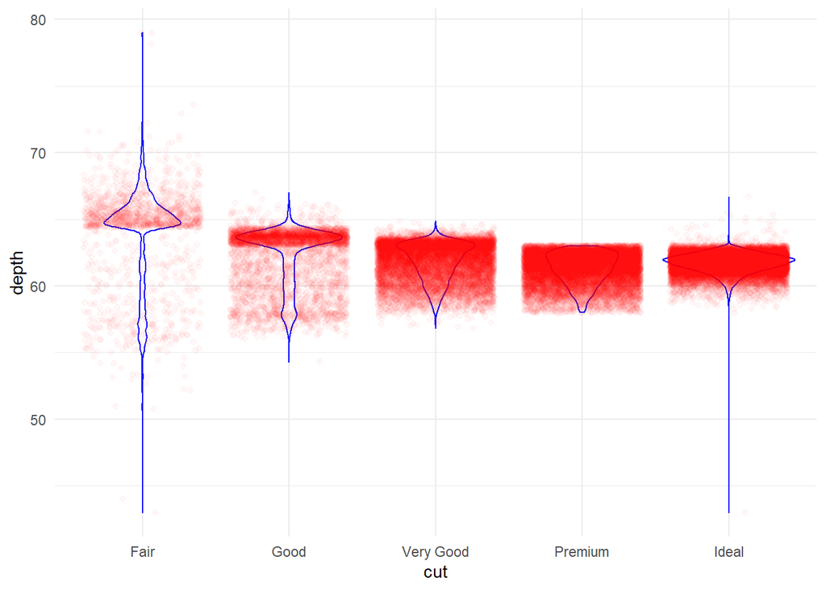

```r
ggplot(diamonds,aes(cut, depth)) +
geom_violin(color = "blue") +
geom_jitter(color = "red", alpha = 0.03)
```

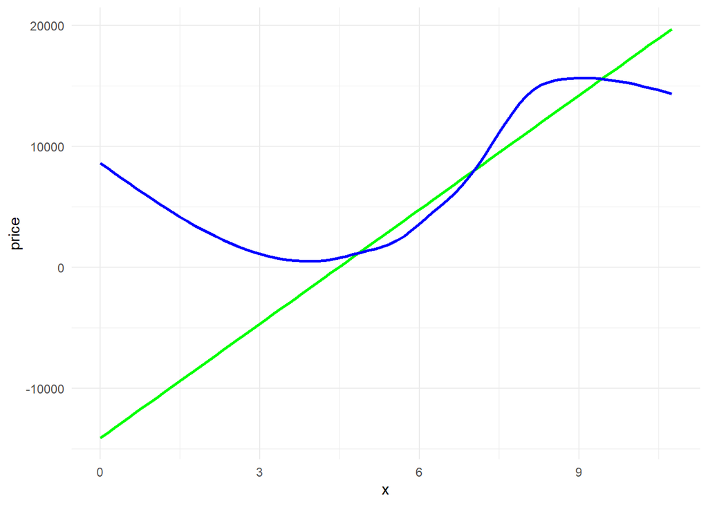

```r
ggplot(diamonds, aes(x, price)) +
geom_smooth(method = "lm", color = "green") +
geom_smooth (color = "blue", se =FALSE)
```